# Machine learning project: building a prediction model to assess the quality of dumbbell lifts

Andreas D Storz

September 21, 2014

## Introduction

*This report details the steps taken to build a prective model in R using the caret package. It is the central compomenent of the course project for the Practical Machine Learning class in Coursera’s Data Science Specialization. The substantive goal here is to correctly predict the manner in which volunteers performed dumbbell lifts, and specifically to identify common mistakes. The final model’s out-of-sample error rate is estimated to be around 4%.*

## Data and Reproducibility

The data set used here contains measurements from accelerometers that were gathered from study participants performing unilateral dumbbell biceps curls. The data were collected in order to build a predictive model that can assess how well people performed the specific task given and to (eventually) provide instant feedback.

Specifically, six volunteers performed ten repetitions of simple dumbbell lifts in five different ways: “exactly according to the specification (Class A), throwing the elbows to the front (Class B), lifting the dumbbell only halfway (Class C), lowering the dumbbell only halfway (Class D) and throwing the hips to the front (Class E).” The goal here is to predict the way they performed the task using the measurements on the accelerometers as predictors.

The original data set can be obtained here: http://groupware.les.inf.puc-rio.br/har. The analysis was conducted in “R Studio”. All calculations are displayed in order to illustrate the actual data analysis process, and to allow for reproducibility. The report itself was created using the ‘knitr’ package while the modeling process made use of the ‘caret’ package.

## Data preprocessing

First, we load the data along with the necessary libraries and look for missing values.

```r
set.seed(3995)
library(caret); library(ggplot2)
myData <- read.csv("pml-training.csv")
dim(myData)
```

```
## [1] 19622   160
```

```r
csNAs <- colSums(is.na(myData))
length(csNAs[csNAs==19216])
```

```
## [1] 67
```

```r
table(csNAs)
```

```
## csNAs
##     0 19216
##    93    67
```

```r
indexNAs <- csNAs!=19216
myDataSub <- myData[,indexNAs]
myDF <- myDataSub[,-c(1,3:7)]
colClasses <- sapply(myDF, class)
indexFactor <- colClasses!="factor"
indexFactor[c(1,87)] <- TRUE
myDF <- myDF[,indexFactor]
```

Finally, a test for near zero variables is performed. It returns a negative result for all the remaining variables, indicating that they are all of potentially predictive value.

```r
nzvs <- nearZeroVar(myDF,saveMetrics=T)
table(nzvs[,3:4])
```

```
##        nzv
## zeroVar FALSE
##   FALSE    54
```

This final data sub-set now contains only 54 variables, including the outcome variable. In the next step, I split the data set into a training and a test set on the outcome variable. The model building only happens in the training set while the final model will be evaluated using the test - or validation - set. Around 75% of the observation will be in the training set; the test set contains the remaining 25% of the data.

```r
inTrain <- createDataPartition(y=myDF$classe, p=.75, list=FALSE)
training <- myDF[inTrain,]
testing <- myDF[-inTrain,]
```

## Model fitting

The basic choice for model fitting concerns the algorithm to be used. There are a multitude of prediction algorithms to choose from, and for virtually every case there are different, equally valid alternatives available. For the purpose of this project, I selected so-called Stochastic Gradient Boosting or “boosted trees”, as the method of choice. The reason for this is that “boosted trees” is – along with other boosting methods - one of the most accurate and therefore most widely used methods for prediction. In addition to that, it is very versatile as it can be used for both classification and regression.

The basic principle behind boosting is to combine individually weak classifiers in a series of iterations in which the individual learners are weighted, added up, and finally averaged. This weighted and averaged combination of individual classifiers results in a single, much stronger classifier.

In the case of the “boosted trees” algorithm, these individual classifiers are built with *classification trees*. The algorithm fits a series of trees where each new tree is improving the fit of the model by increasing the overall predictive value. The model’s final prediction is a weighted average of each tree’s prediction where the weights are based on the quality of each tree.

In R, the “boosted trees” algorithm is specified by setting the method to be “gbm”. There are three tuning parameters that need to be defined: the number of boosting iterations, i.e. the number of trees; their depth or number of splits; and the algorithm’s learning rate (or “shrinkage”), i.e. a rate specifying how quickly the algorithm adapts.

By default, each fit is based on bootstrapped resamples. This method tends to underestimate the error. For this reason, I change the resampling method to **cross-validation**, which helps prevent overfitting the model. Specifically, each fit is set to 5 repeats of 10-fild cross-validation.

The model is built using the ‘train’ function from the caret package. Given that this is an early, exploratory stage of the model building process and we do not have specific reasons to exclude specific variables, all the remaining ones are considered as preditors and consequently included in the model (indicated by the “.” in the formula):

```r
ctrl <- trainControl(method="repeatedcv",
                     repeats=5)
modFit <- train(classe~., data=training,
                method="gbm", verbose=FALSE, trControl=ctrl)
```

## Model evaluation

The fitted model can easily be evaluated using the following commands:

```r
print(modFit)
```

```
## Stochastic Gradient Boosting
##
## 14718 samples
##    53 predictor
##     5 classes: 'A', 'B', 'C', 'D', 'E'
##
## No pre-processing
## Resampling: Cross-Validated (10 fold, repeated 5 times)
##
## Summary of sample sizes: 13246, 13246, 13245, 13247, 13247, 13246, ...
##
## Resampling results across tuning parameters:
##
##   interaction.depth  n.trees  Accuracy  Kappa  Accuracy SD  Kappa SD
##   1                   50      0.8       0.7    0.012        0.016
##   1                  100      0.8       0.8    0.010        0.013
##   1                  150      0.9       0.8    0.009        0.011
##   2                   50      0.9       0.8    0.009        0.012
##   2                  100      0.9       0.9    0.008        0.010
##   2                  150      0.9       0.9    0.006        0.008
##   3                   50      0.9       0.9    0.008        0.011
##   3                  100      0.9       0.9    0.006        0.007
##   3                  150      1.0       1.0    0.004        0.006
##
## Tuning parameter 'shrinkage' was held constant at a value of 0.1
## Accuracy was used to select the optimal model using  the largest value.
## The final values used for the model were n.trees = 150,
##  interaction.depth = 3 and shrinkage = 0.1.
```

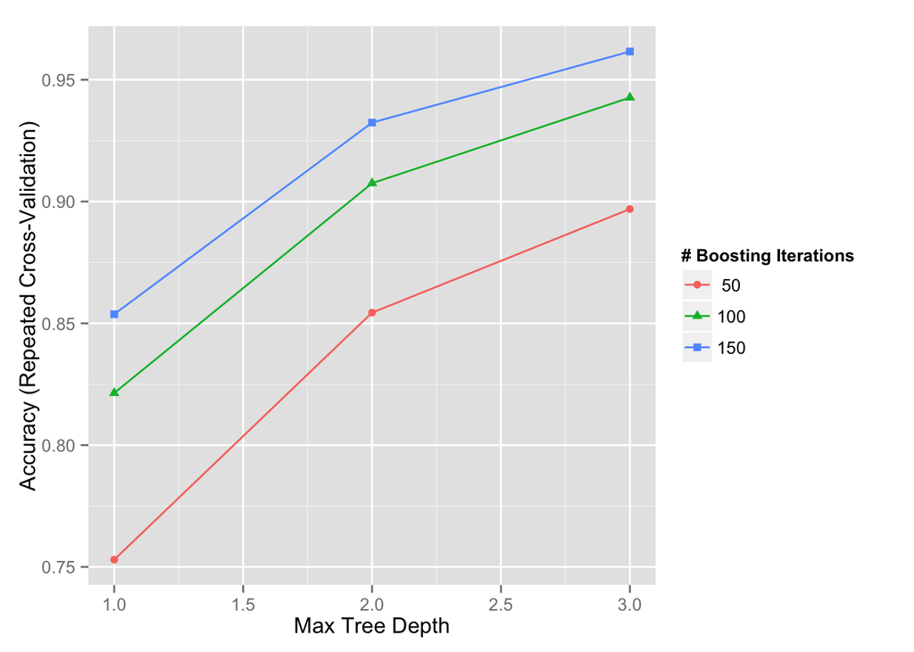

```r
ggplot(modFit)
```

The output shows that the fit with 150 classification trees having a depth of 3 splits along with a learning rate of 0.1, i.e. a relatively fast learner, was chosen as the final model as it had the highest overall accuracy. This is also evident from the plot displaying the different model fits.

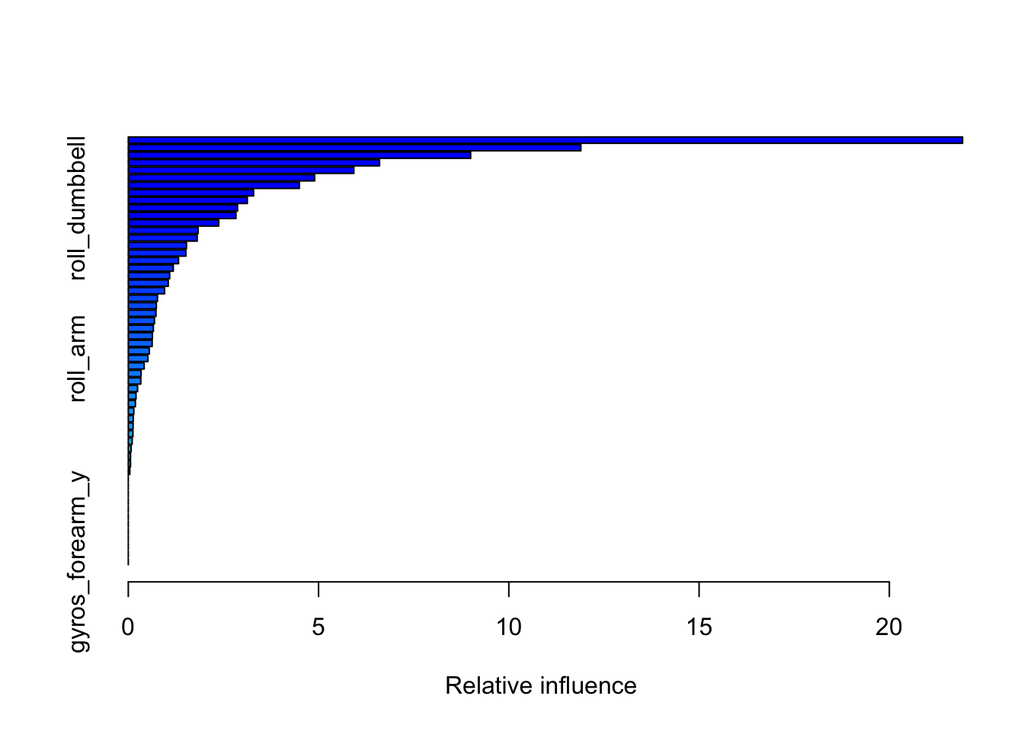

```
##                                       var  rel.inf
## roll_belt                       roll_belt 21.92419
## pitch_forearm               pitch_forearm 11.89337
## yaw_belt                         yaw_belt  8.99663
## magnet_dumbbell_z       magnet_dumbbell_z  6.60236
## magnet_dumbbell_y       magnet_dumbbell_y  5.92790
## roll_forearm                 roll_forearm  4.89770
## magnet_belt_z               magnet_belt_z  4.49737
## gyros_belt_z                 gyros_belt_z  3.29171
## pitch_belt                     pitch_belt  3.12809
## roll_dumbbell               roll_dumbbell  2.87126
## accel_forearm_x           accel_forearm_x  2.82955
## accel_dumbbell_y         accel_dumbbell_y  2.37719
## gyros_dumbbell_y         gyros_dumbbell_y  1.83435
## accel_dumbbell_x         accel_dumbbell_x  1.81029
## magnet_forearm_z         magnet_forearm_z  1.53037
## yaw_arm                           yaw_arm  1.51332
## magnet_arm_z                 magnet_arm_z  1.32056
## magnet_dumbbell_x       magnet_dumbbell_x  1.18208
## magnet_forearm_x         magnet_forearm_x  1.08726
## accel_forearm_z           accel_forearm_z  1.05013
## magnet_arm_x                 magnet_arm_x  0.95405
## magnet_belt_x               magnet_belt_x  0.76748
## magnet_belt_y               magnet_belt_y  0.73715
## magnet_arm_y                 magnet_arm_y  0.72736
## gyros_belt_y                 gyros_belt_y  0.68811
## accel_dumbbell_z         accel_dumbbell_z  0.65849
## user_nameeurico           user_nameeurico  0.63395
## accel_belt_z                 accel_belt_z  0.62728
## gyros_arm_y                   gyros_arm_y  0.55240
## roll_arm                         roll_arm  0.51446
## total_accel_dumbbell total_accel_dumbbell  0.41687
## accel_forearm_y           accel_forearm_y  0.33684
## total_accel_forearm   total_accel_forearm  0.32817
## gyros_dumbbell_z         gyros_dumbbell_z  0.24361
## magnet_forearm_y         magnet_forearm_y  0.20289
## gyros_dumbbell_x         gyros_dumbbell_x  0.18708
## gyros_forearm_z           gyros_forearm_z  0.14544
## total_accel_belt         total_accel_belt  0.13117
## accel_arm_z                   accel_arm_z  0.12614
## total_accel_arm           total_accel_arm  0.12176
## pitch_dumbbell             pitch_dumbbell  0.10160
## accel_arm_x                   accel_arm_x  0.07489
## gyros_arm_x                   gyros_arm_x  0.05856
## gyros_belt_x                 gyros_belt_x  0.05833
## yaw_dumbbell                 yaw_dumbbell  0.04026
## user_namecarlitos       user_namecarlitos  0.00000
## user_namecharles         user_namecharles  0.00000
## user_namejeremy           user_namejeremy  0.00000
## user_namepedro             user_namepedro  0.00000
## accel_belt_x                 accel_belt_x  0.00000
## accel_belt_y                 accel_belt_y  0.00000
## pitch_arm                       pitch_arm  0.00000
## gyros_arm_z                   gyros_arm_z  0.00000
## accel_arm_y                   accel_arm_y  0.00000
## yaw_forearm                   yaw_forearm  0.00000
## gyros_forearm_x           gyros_forearm_x  0.00000
## gyros_forearm_y           gyros_forearm_y  0.00000
```

```r
summary(modFit)
```

The summary output shows the relative influence of the different predictors. This information could be used to fine-tune the model in collaboration with project experts that have more domain-specific knowledge.

## Predicting on the test set

For a final test, this chosen model is applied to the test set data in order to get a measure of the out-of-sample error. The results of these calculations are displayed in a confusion matrix.

```r
pmlPred <- predict(modFit, testing)
confusionMatrix(pmlPred, testing$classe)
```

```
## Confusion Matrix and Statistics
##
##           Reference
## Prediction    A    B    C    D    E
##          A 1377   29    0    1    1
##          B   12  897   22    2    3
##          C    2   23  820   31   14
##          D    4    0   10  763   13
##          E    0    0    3    7  870
##
## Overall Statistics
##
##                Accuracy : 0.964
##                  95% CI : (0.958, 0.969)
##     No Information Rate : 0.284
##     P-Value [Acc > NIR] : < 2e-16
##
##                   Kappa : 0.954
##  Mcnemar's Test P-Value : 6.78e-05
##
## Statistics by Class:
##
##                      Class: A Class: B Class: C Class: D Class: E
## Sensitivity             0.987    0.945    0.959    0.949    0.966
## Specificity             0.991    0.990    0.983    0.993    0.998
## Pos Pred Value          0.978    0.958    0.921    0.966    0.989
## Neg Pred Value          0.995    0.987    0.991    0.990    0.992
## Prevalence              0.284    0.194    0.174    0.164    0.184
## Detection Rate          0.281    0.183    0.167    0.156    0.177
## Detection Prevalence    0.287    0.191    0.181    0.161    0.179
## Balanced Accuracy       0.989    0.968    0.971    0.971    0.982
```